# Simple API level usage of the XFEL Data Exploration Toolbox

*n.b.* you will need `cctbx.xfel` installed to run this, and will need to run it with the command `libtbx.ipython`.

API documentation can be found at http://cci.lbl.gov/cctbx_docs/xfel/xfel.clustering.html#cluster-cluster Note that this is in active development, so may be updated freequently/contain new methods or classes that are not yet finished.

This tutorial will demonstrate the API level usage of the XFEL data exploration toolkit, using a test data set with only 49 images, for simplicity. On my local machine, this is at:

```python
TESTDATA = ['/users/oli/Dropbox/Stanford_Postdoc/CODING/cctbx_testing/PolG_test_data']
```

```python
import logging
import numpy as np
import matplotlib.pyplot as plt
import logging
import brewer2mpl
# Set up logging
reload(logging)  # work-around for IPython
FORMAT = '%(message)s'
logging.basicConfig(level=logging.INFO, format=FORMAT)
# pretty colors
cols = brewer2mpl.get_map('BrBG', 'Diverging', 3).mpl_colors
```

Let's start by creating a cluster object. We will use the `from_directories` class method to create a cluster object.

```python
from xfel.clustering.cluster import Cluster
t_clus = Cluster.from_directories(TESTDATA)
```

Next, we'll do some hierarchical clustering on this to get a sense of the unit cells and point groups that make up our data. sub_clusters will be a list of clusters, and we're ignoring the other return value (the axes object we just plotted onto).

```
Hierarchical clustering of unit cells
Using Andrews-Bernstein distance from Andrews & Bernstein J Appl Cryst 47:346 (2014)
Distances have been calculated
```

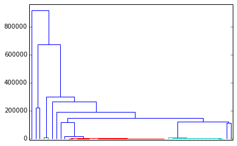

```python
sub_clusters, _ = t_clus.ab_cluster(labels=False, write_file_lists=False)
```

So let's look at the composition `sub_clusters` list we got. Since this is acting on a *group of clusters*, we will import a tool from the `cluster_groups` module.

```python
from xfel.clustering.cluster_groups import unit_cell_info
pretty_str = unit_cell_info(sub_clusters)
print pretty_str
```

```
12 clusters.
C_id  Num in cluster Med_a       Med_b       Med_c       Med_alpha    Med_beta     Med_gamma
cluster_10       2        230.7(1.1 ) 290.2(3.7 ) 784.3(1.4 ) 90.00 (0.00) 90.00 (0.00) 90.00 (0.00)
2 in P222.
cluster_11       14       224.6(4.6 ) 286.5(1.8 ) 400.0(7.0 ) 90.00 (0.00) 90.00 (0.00) 90.00 (0.00)
10 in C222, 4 in P222.
cluster_12       24       227.4(1.6 ) 227.4(1.6 ) 286.8(2.4 ) 90.00 (0.00) 90.00 (0.00) 120.00(0.00)
24 in P3.
Standard deviations are in brackets.
9 singletons:

 Point group   a           b           c           alpha        beta         gamma
C2             225.7       270.5       1187.4     90.0         90.0         94.0
C222           231.2       286.7       1131.1     90.0         90.0         90.0
P2             225.9       229.4       287.2      90.0         90.0         119.4
C2             228.4       299.2       392.5      93.1         90.0         90.0
C2             23.7        330.1       358.3      97.9         90.0         90.0
C2             226.3       290.9       399.7      91.3         90.0         90.0
P222           226.8       396.7       572.0      90.0         90.0         90.0
C2             223.1       486.0       682.3      92.7         90.0         90.0
P1             484.1       600.6       689.2      99.9         91.1         104.5
```

```python
clu_b, clu_a = sub_clusters[-2:]
print "clu_a size: {}\nclu_b size: {}".format(len(clu_a.members), len(clu_b.members))
```

```
clu_a size: 24
clu_b size: 14
```

Let's now pretend we are interested only in the smaller cluster, `clu_b`. Let us examine the intensity distribution for this, again ignoring the returned axes object:

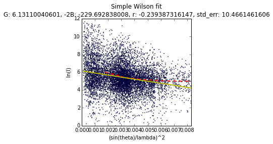

```python
_ = clu_b.all_frames_intensity_stats()
```

That's not looking great: a very high B value, and some rising in the intensities at higher resoltion. These are in fact pretty poor quality data, so that's consitent. Now let's look at the point group composition and see if either of these look better separately:

```python
clu_b.pg_composition
```

```
{'C222': 10, 'P222': 4}
```

```python
clu_bC = clu_b.point_group_filter('C222')
clu_bP = clu_b.point_group_filter('P222')
```

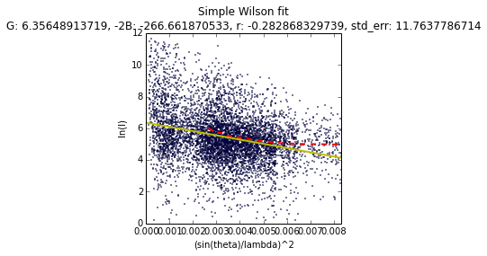

```python
_ = clu_bC.all_frames_intensity_stats()
```

Still looking a bit woking at high res..

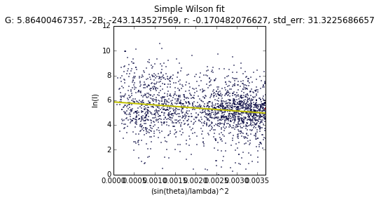

```python
_ = clu_bP.all_frames_intensity_stats()
```

This looks a little more sensible. Now, let's look at the info string:

```python
print clu_bP.info
```

```
Made from files in ['/users/oli/Dropbox/Stanford_Postdoc/CODING/cctbx_testing/PolG_test_data']
############################## Next filter ##############################
Made using ab_cluster with t=10000, distance method, and single linkage
14 of 49 images passedon to this cluster
############################## Next filter ##############################
Cluster filtered by for point group P222.
4 of 14 images passedon to this cluster
```

Note how this keeps track of the cluster's provenance, so we know where it came from. Let's now write these images of interest out (so that we can, for example look at them individually using `cctbx.image_viewer`,

```python
clu_bP.dump_file_list(out_file_name='temp.lst')
```

```python
cat temp.lst
```

```
/users/oli/Dropbox/Stanford_Postdoc/CODING/cctbx_testing/PolG_test_data/int-s00-2013-11-10T17:53Z14.813_00000.pickle
/users/oli/Dropbox/Stanford_Postdoc/CODING/cctbx_testing/PolG_test_data/int-s03-2013-11-10T17:51Z07.396_00000.pickle
/users/oli/Dropbox/Stanford_Postdoc/CODING/cctbx_testing/PolG_test_data/int-s03-2013-11-10T17:54Z36.359_00000.pickle
/users/oli/Dropbox/Stanford_Postdoc/CODING/cctbx_testing/PolG_test_data/int-s04-2013-11-10T18:28Z45.434_00000.pickle
```

Marvelous!